# Introduction to Command Line

Authors & reviewers*: Jonathon Mellor, Tom Albone, Jeroen Minderman, Tom White, Georgina Dangerfield

Course Updated: November 2022 | Need help? Contact the team.

# Learning Outcomes

This course will cover the basics needed to use the command line interface (CLI) on a computer. The learning objectives are:

- To understand the importance of the command line interface (CLI) as a more powerful alternative to graphical user interfaces (GUI)
- To navigate and manipulate directory structures
- To be able to run scripts in the CLI
- To write commands to allow the effective use of statistical programming languages and associated tools

You will need access to a command line interface in order to complete the exercises in this course.

# 1 Introduction

Command line programming is often viewed as an intimidating subject for many learning to code. It doesn’t need to be, many operations that you already do on your computer such as opening folders, running programs and editing files can be done using the command line.

## 1.1 What is the Command Line?

Interacting with the command line interface is a generic term we will use to describe something that can be more easily understood as “communicating directly with the computer”.

Typically when we interact with a computer we do so with a program, such as Microsoft Word, File Explorer or Google Chrome. What we are actually doing is clicking or typing with a Graphical User Interface, GUI. The GUI receives our instructions then passes them on to the computer.

GUIs are nice to look at and reduce the amount of working with the computer itself we need to do.

Using the command line interface we are able to directly interact with the computer.

## 1.2 Why should we use the Command Line?

Many processes are designed to be used by only the command line. With it, you can develop code in a more flexible manner, less dependent on other programs.

The command line does not replace these programs, but will be a useful additional tool for more advanced capabilities.

# 2 Basic Commands

First let’s cover some basic principles.

## 2.1 UNIX and Windows Differences

The type of operating system we are using will affect the commands we use. We can refer to this as the “flavour” of commands we use. Certain programs were designed for specific operating systems and carry this flavour with them.

The program we use to interact with the command line will determine which flavour we use. In principle, each flavour can achieve the same thing, but with slightly different commands.

Below is a breakdown of which program is which flavour. Throughout this course we will give commands for each flavour: UNIX-like and Windows. UNIX-like are typically programs designed for MacOS or Linux, but can be found on Windows machines. Choose the one that is right for the program you are using.

| UNIX-like | Windows |
| --- | --- |
| Git Bash | Anaconda Prompt |
| Terminal (MacOS) | Windows Command Prompt |
| Bash | Power Shell |

UNIX-like command line interfaces typically allow you to type following the `$` symbol in the program, whereas Windows flavours use a `>`.

## 2.2 Comparison of different Shells

### CMD

- Command line for Microsoft Windows operating system, with command-based features
- Inputs/Outputs treated like characters
- Text-based command-line interface
- Default program in all Windows OS

### Powershell

- Task-based command-line interface, based on .Net Framework and designed for system admins
- Treats input and output as objects (similar to Python/Java)
- More interactive, graphical command-line interface than CMD
- Built-in to Windows 7 and above

### Bash

- Command-line and scripting language for Unix/Linux-based OS
- Inputs/Outputs treated like characters
- Text-based command-line interface
- Default for Linux/Unix systems

### Anaconda Prompt

Extends the standard command line-interface of your OS to use anaconda and conda commands (See the [Anaconda docs](https://docs.anaconda.com/anaconda/) for more detail)

**NOTE** As we are using networked/restricted devices, some of the things we can generally do in command line are not allowed on our computers. Some programs for accessing the command line do not allow the full functionality as they are designed for a specific purpose. For example: Git Bash allows basic directory commands and accessing Git, but not things like running other programs.

For Windows users it is useful to learn both the UNIX-like and Windows syntax, but first learn one.

If you are on a Mac, please use the Terminal for this course, if you are on a Windows, please use Command Prompt.

## 2.3 Opening the Command Prompt/Terminal

### MacOS terminal

Either open the utilities folder and find the terminal icon (shown below) or search the system for ‘terminal’

[figure not shown]

### Windows 10 Command Prompt

In the start menu, either search for ‘cmd’ (shown below) or find the icon under the Windows System folder.

[figure not shown]

If you are on a Windows machine and are unable to access a UNIX-like command line interface (such as Git Bash) you can interact with a terminal online [here](https://cocalc.com/doc/terminal.html) if you would like to practice this flavour.

## 2.4 Command Syntax

Typically, you use the command line by typing a single line at a time. The computer interprets and actions each line after you type the `Enter` key. Most command line interpreters also allow for the running of scripts (multiple lines of commands) to run through a sequence of actions, allowing it to be used as a programming language.

We will show and list some general syntax when using the language without specifying actual commands. You will see commands referred to online and in literature using a similar manner, but convention varies.

The command line interpreter (Bash, Windows Command Prompt, Git Bash etc.) will start a line with either `$` or `>` depending on flavour. For simplicity in this section we will start lines with `$`.

We typically start a command with text representing either a program or instruction. Required text is denoted without any wrapper (such as brackets, quotation marks, etc).

```bash
$ command
```

If we wanted to do this command to a certain object, we would add another argument. Arguments are separated by spaces. Placeholders are commonly denoted with angle brackets (`<` and `>`) surrounding the object.

```bash
$ command <put your argument here>
```

If we wanted to do the command to the object called `test_object` we would type:

```bash
$ command test_object
```

Note that there is no `<` `>` as we just use that to represent a placeholder, not a real object.

Optional arguments for a command are denoted with square brackets surrounding them. Our command therefore becomes:

```bash
$ command [optional argument goes here] <put argument here>
```

We typically put optional arguments *not* at the end by convention.

Implementing this syntax with the optional argument `-o` becomes:

```bash
$ command -o test_object
```

`-o` is called a *flag*, which is a type of optional argument. Flags have a dash `-` before their name. You will see these come up frequently in UNIX-like systems. They are a type of argument that modifies the behaviour of what the command does in some way. The Windows alternative is adding an argument with `/` such as `command /A`.

If you are coming to this course with some experience in other programming languages, you can consider command line commands similar to functions.

First, you write the function name (the base command), then you add required arguments for the function to run, then add optional parameters. Instead of using commas to separate arguments, we use spaces.

To summarize:

- write a command in the command line,
- each command statement has some instruction, and can have arguments and optional arguments depending on the command,
- each part of the command statement is separated by a space,
- to run the command statement press `Enter` once it is fully written.

In addition, you can autocomplete commands and file names by pressing the Tab key.

Instead of rewriting the same instruction or similar multiple times you can press the up arrow in command line to retreive a previously executed command. You can keep pressing up to go further and further back into previous commands.

## 2.5 Help

Before we get to writing commands, we will first mention how to get more information about the commands we want to use.

### UNIX-like

You have two options when looking for more information in terminal/bash. The first is:

```bash
$ man <command>
```

`man` is short for “manual”, which tells you information about the command you are specifying, including optional arguments.

Many commands also supply a `-h` or `-help` flag which will return useful information about the command.

```bash
$ <command> -h
```

### Windows

We can use the `help` command to get more information. If we do not supply an optional argument then the command will return a list of other commands that can be executed.

If we add an optional command following `help` it will return us the help information supplied for that command, if it exists.

```bash
>help [command]
```

## 2.6 Exercises

### Questions

1. Open your command line interface.
2. Get help for the following command: `cd`

### Answers

#### UNIX-like

**Question 1** Open your command line interface.

Open your search bar and select “Terminal”. Run the program.

**Question 2**

Get help for the following command: `cd`

```bash
$ cd -h
```

#### Windows

**Question 1**

Open your command line interface.

Open your search bar and select “Command Prompt”. Run the program.

**Question 2**

Get help for the following command: `cd`

```bash
>help cd
```

# 3 Navigating Directories

The most commonly used commands used in this interface are to navigate through folders to specific locations in your computer’s memory. This is often to get to a file or directory in order to execute a command of some sort.

You will most likely be familiar with how you interact with folders on your computer; for Windows users File Explorer and Mac users Finder. The actions you use to move around in these programs can be replicated using the command line, you move into and out of folders.

In this course we will use “Folder” and “Directory” interchangeably.

## 3.1 Paths

The *root* directory is the highest level directory you can go to in a file system. It is from there that any other file can be located by going deeper and deeper into folders.

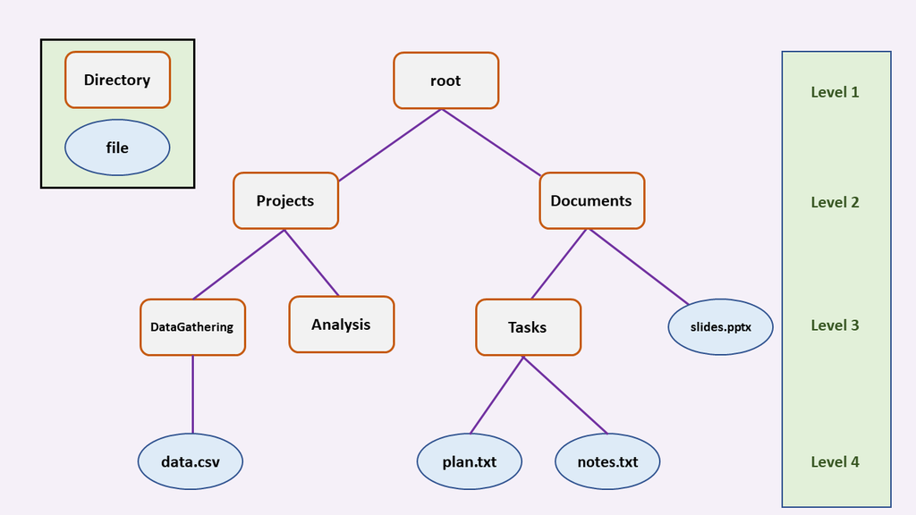

**NOTE:** In this example the *root* directory is called “root”, this is not the case in real file systems.

You can imagine file systems as an upside down tree, with the root at the top and branches (representing directories) connected below, each with directories attached to each branch and so on. At each point in the branch there can be files located.

We denote the position of a file in our file system by using it’s “path”. The path is a description of where the file exists, and is also called an address.

The location we are currently in is called the *working directory*, as it is the place we can work from most easily.

We will discuss two types of paths: *absolute* and *relative*.

> **Absolute** paths are the full address of a location in the file system. This means that the address describes how to get from the *root* directory to the location specified. It lists each directory that you must travel through in order which will get you to the file destination.

Absolute paths are fully descriptive. It doesn’t matter where you are in your file system, you will be able to get to the place you want to go.

> **Relative** paths are a partial address in the file system. Relative paths *do not* tell you how to get to a location from the root directory, but rather give directions from where you *currently* are.

Relative paths allow you to get from one location to another *without* full knowledge of the whole path to the root directory. This means we can from one folder get to another without going via the very top of the inverted tree.

The syntax of path structure is dependent on operating system and language being used. It is good to know both styles.

Paths are written left to right, where the furthest left is either the root directory for absolute paths, or the highest directory travelled through with relative paths.

Generally UNIX-like styles use forward-slashes `/` between directory names. The root directory is simply given as a single slash `/`.

The file location of `data.csv` above would be given as:

```bash
/root/Projects/DataGathering/data.csv
```

In Windows systems a back-slash `\` is used to separate directory names that are travelled through. The root directory is the *drive* that the file system is in. This means that all absolute paths will start with the drive.

The file path would be given as:

```bash
\root\Projects\DataGathering\data.csv
```

**NOTE:** There are no spaces between or within filenames, this is one of the reasons that naming conventions avoid spaces in programming.

If a file or folder you are using has a space within it you must put the full filepath in quotation marks `" "` such as “/Name of folder/filename.txt”.

**NOTE:** in relative file paths we can denote the current directory using `.`, so a file path starting with the current directory could start with `./` for UNIX-like or `.\` for Windows.

## 3.2 Changing directory

As mentioned before we can move between directory locations on our system using a range of command line commands. Think about travelling in general, what information do you need to know?

Some key points that are needed include:

- Where are you currently?
- What is around you?
- How do you move from there?

**Remember:** in a file system we can only move up or down, either out of a folder or into one. The way we travel is dependent on going up to a high enough level that we can then access what we want to go down to.

### 3.2.1 Current Directory

Before we move anywhere we should know where we currently are.

**NOTE:** The below code is a worked example using the file system “root”, you will have the chance to practice the commands during the exercises at the end of this section.

#### UNIX-like

We can get the address of our current location using the command `pwd`. This stands for *present working directory*. This will return us the current *working directory* - our location.

```bash
$ pwd
```

```
/C/example_folder/greater_depth
```

My present working directory is within within the `C` drive (we can think of this as a folder in this case), in a folder called `/example_folder/` in a sub folder `/greater_depth/`.

A drive is a location within a computer capable of storing and reading information. Windows devices allow the user to explicitly choose which drive to store information in.

#### Windows

We can get the address of our current location using the command `cd` *without any additional arguments*. This will return us the current *working directory* - our location.

```bash
>cd
```

```
C:\example_folder\greater_depth
```

My present working directory is within the`C:\` drive, within a folder called `/example_folder/` in a sub folder `/greater_depth/`.

A drive is a location within a computer capable of storing and reading information. Windows devices allow the user to explicitly choose which drive to store information in.

### 3.2.2 Contents of Current Directory

Showing the contents of the directory we are currently in can help:

- locate files we are searching for.
- orient where we are in the file system.

We can add different optional parameters in order to display different things in the directory.

#### UNIX-like

In order to list the contents of a directory we use the `ls` command.

```bash
$ ls
```

Which will return all of the visible files and folders in a directory.

Some items are intentionally *hidden* in our directories, this is often denoted by a `.` before the name of the file/folder. For example a `.git` folder. We can view all items, including those which are *hidden* by using the following flag.

```bash
$ ls -a
```

Which will return all items in the current directory including hidden ones.

Some other useful flags include:

- `-l` which gives the “long” version of the files, including permissions and sizes.
- `-s` gives the size of each item.
- `-S` sorts the items by size.

#### Windows

In order to list the contents of a directory we use the `dir` command.

```bash
>dir
```

Which will return all of the files and folders in a directory with information about when each item was last edited, what type it is and any file sizes.

Adding the optional argument `/A` followed by another letter modifies the command.

For example, to display all the hidden items in a directory type:

```bash
>dir /AH
```

### 3.2.3 cd

We can now work out what directory we are currently in, and what items are stored in that directory. We now will want to move between the directories. This is one of the most common operations done in command line.

In both UNIX-like and Windows systems to “change directory” we use the command `cd`.

The `cd` command is followed by an argument which denotes were we want to go. This is where our knowledge of paths comes in.

To get anywhere in our file system we can type `cd` followed by an *absolute path*, one that contains a full address from the root. No matter where we are in our file system doing this will direct us exactly where we need to go. For example, looking at our example file system from before:

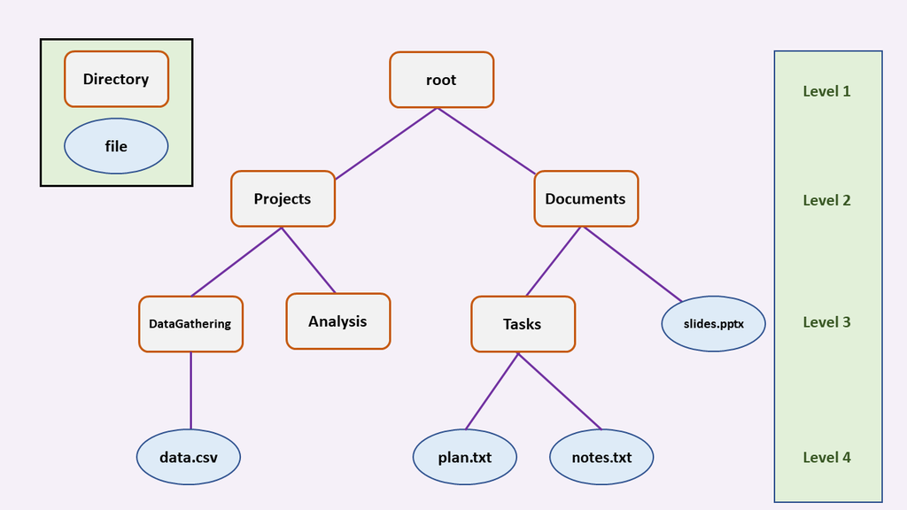

#### UNIX-like

We are starting in the “root” directory.

```bash
$ pwd
```

```
/root
```

If we want to move to the `DataGathering` directory we would figure out what path we needed to go down:  
`/root/Projects/DataGathering/`  
Then type the command:

```bash
$ cd /root/Projects/DataGathering/
```

This will change the location that your command line program displays above/next to the line you type in. We can check that we have changed the current directory by typing:

```bash
$ pwd
```

```
/root/Projects/DataGathering/
```

**Remember:** The “root” directory is the highest one in a file system, the one we are using in this example is imaginary.

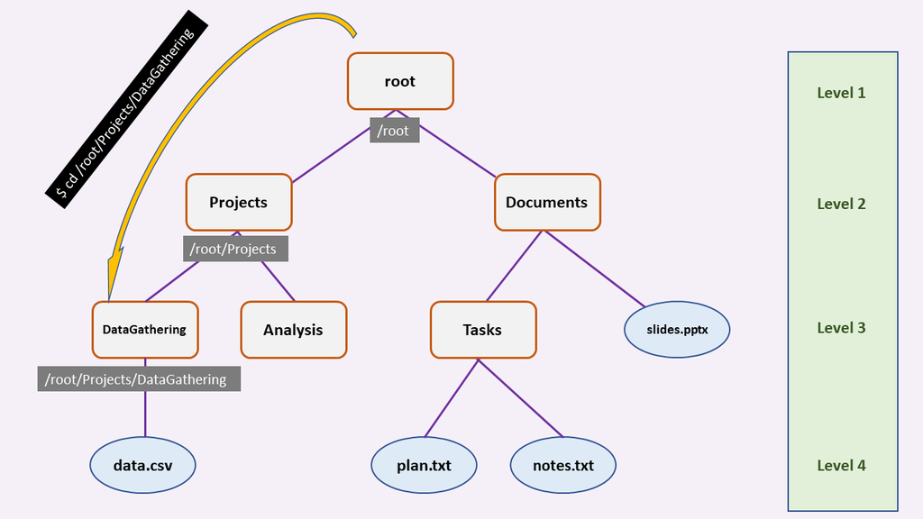

We can also move between folders based on the relative path from where we are. To go “up” a file level we use the `..` syntax.

Starting in the `/DataGathering/` folder to go back up to the `/Projects/` folder we would type:

```bash
$ cd ..
```

```bash
$ pwd
```

```
/root/Projects/
```

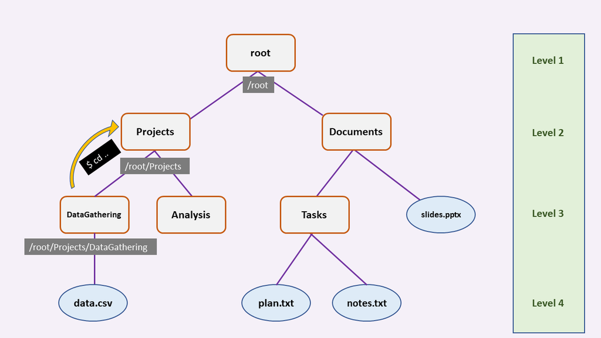

To go “down” a level, into another folder we simply type the folder name as an argument.

```bash
$ cd Analysis
```

```bash
$ pwd
```

```
/root/Projects/Analysis/
```

We can add these two things together, by going “up” then “down” files to get anywhere in our file system.

To get from `/Projects/` to `/root/Documents/` we would write:

```bash
$ cd ../Documents
```

```bash
$ pwd
```

```
/root/Documents/
```

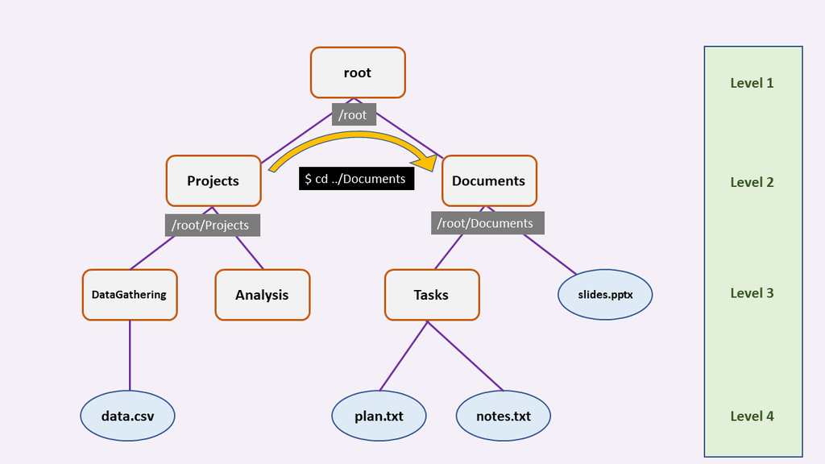

To go up two levels we can write `../..` - using the `..` synatx twice.

**NOTE:** Each part of the path is separated by a forward-slash `/` with no spaces in between.

#### Windows

We are starting in the “root” directory.

**Remember:** We use `cd` without any arguments to display the current working directory

```bash
>cd
```

```
\root
```

If we want to move to the `DataGathering` directory we would figure out what path we needed to go down:  
`\root\Projects\DataGathering`  
Then type the command:

```bash
>cd \root\Projects\DataGathering\
```

This will change the location that your command line program displays above/next to the line you type in. We can check that we have changed the current directory by typing:

```bash
>cd
```

```
\root\Projects\DataGathering\
```

**Remember:** The “root” directory is the highest one in a file system, the one we are using in this example is imaginary.

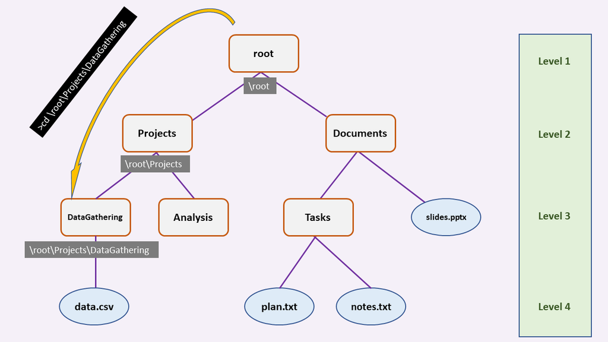

We can also move between folders based on the relative path from where we are. To go “up” a file level we use the `..` syntax.

Starting in the `\DataGathering\` folder to go back up to the `\Projects\` folder we would type:

```bash
>cd ..
```

```bash
>cd
```

```
\root\Projects
```

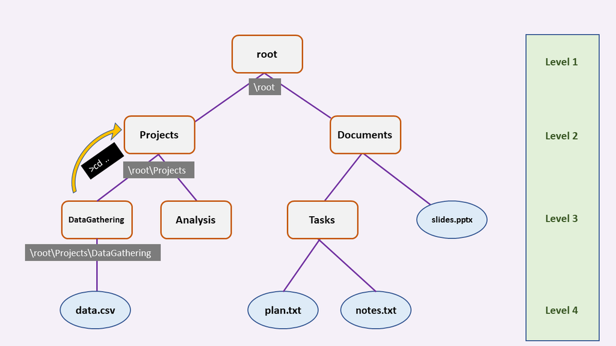

To go “down” a level, into another folder we simply type the folder name as an argument.

```bash
>cd Analysis
```

```bash
>dir
```

[output not shown]

We can add these two things together, by going “up” then “down” files to get anywhere in our file system.

To get from `\Projects\` to `\root\Documents\` we would write:

```bash
>cd ..\Documents
```

```bash
>cd
```

```
\root\Documents\
```

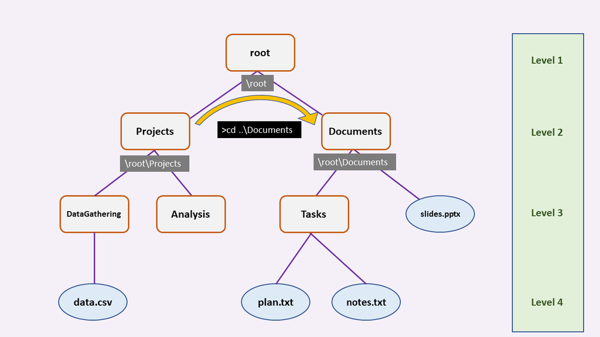

To go up two levels we can write `..\..`.

**NOTE:** Each part of the path is separated by a backwards-slash `\` with no spaces in between.

### 3.2.4 Changing Drives

We need to sometimes distinguish between a directory and a drive on a computer when using the command line interface.

A drive is a physical partition within a computer capable of storing information. Windows devices allow the user to pick which drive to store information in.

#### UNIX-like

To move between drives in a UNIX-like interface the command line treats the drive as a directory. The methods for changing drives are therefore the same as changing directory.

To go from the root of the computer `/` to the `/D/` drive we write the command:

```bash
$ cd D
```

To move from the `/D/` drive to the `/C/` drive we would use the command:

```bash
$ cd ../C
```

#### Windows

Windows makes the distinction between drives and directories. We therefore have different methods of moving between them. Starting in the `D:\` drive we move to the `C:\` drive using:

```bash
>C:
```

Then back to the `D:\` drive with:

```bash
>D:
```

## 3.3 Viewing Structure

We can now look at what is in each individual directory, and move between them. But that means to find the location of an item, or understand the structure of a folder system we would need to move around the whole system step by step.

Instead, we can use commands that visualise the structure of a directory for us.

### UNIX-like

In order to produce nice tree structures using a UNIX-like command line interface you need to download a package. We will *not* be teaching this, as government devices are typically restricted in what they can install, especially at the command line level.

Instead, here are two alternatives which give you insight into the structure of your file system. If you are using a Windows computer, it may be best to use Command Prompt for this.

**Option 1**

We can use the `ls` command with a recursive search to show all sub-folders.

```bash
$ ls -R
```

```
.:
Documents/  Projects/

./Documents:
slides.pptx  Tasks/

./Documents/Tasks:
notes.txt  plan.txt

./Projects:
Analysis/  DataGathering/

./Projects/Analysis:

./Projects/DataGathering:
data.csv
```

This gives more information about what the contents of each folder is.

**Option 2**

We can also use the `find` command, which will recursively search through each sub folder.

```bash
$ find
```

```
.
./Documents
./Documents/slides.pptx
./Documents/Tasks
./Documents/Tasks/notes.txt
./Documents/Tasks/plan.txt
./Projects
./Projects/Analysis
./Projects/DataGathering
./Projects/DataGathering/data.csv
```

This lists the path of each item within the current working directory.

### Windows

In Windows based command line interfaces this is achieved using the `tree` command. The command returns a visualisation from the current working directory down of each folder, and the contents of each folder, for all folders.

Our example file system produces the following tree diagram with out working directory in the root.

```bash
>tree
```

```
.
├───Documents
│   └───Tasks
└───Projects
    ├───Analysis
    └───DataGathering
```

This shows us all the folders in root, and any other folders within them and so on.

If we want to additionally see all the files that are contained within this directory we can add the following flag.

```bash
>tree /F
```

```
.
├───Documents
│   │   slides.pptx
│   │
│   └───Tasks
│           notes.txt
│           plan.txt
│
└───Projects
    ├───Analysis
    └───DataGathering
            data.csv
```

## 3.4 Exercises

### Questions

1. What is your current working directory?
2. Download the course material to your Downloads folder using File Explorer / Finder, you will need to unzip. For those in the ONS and most other computers, the locations are as follows:

Windows: * The Downloads folder has the following path `C:\Users\<your username>\Downloads`.

Mac: * The downloads folder in a mac is typically located here: `/Users/<your username>/Downloads`

Move to the exercises folder and change your working directory to the folder called “file_system”.

*Note:* You do not need to unzip the files using command line (but this can be done!).

3. List the contents of the “file_system” folder.
4. Recursively list / show tree diagram of the “file_system” folder with all sub folders *and* files.
5. From “file_system” navigate to the “Documentation” folder. Then to “Code_review”.
6. From “Code_review” navigate to the “Analysis” then “Plotting” all in one line.
7. From “Plotting” navigate to the “Data” then “text” folders. Then show all files recursively/with a tree diagram in this folder.
8. Return to the “file_system” folder from “text” in one line. Check you are in the right current directory.

### Answers

#### UNIX-like

**Question 1**

What is your current working directory?

```bash
$ pwd
```

On a Mac this is likely to be `/Users/<username>/` On a Windows this is likely to be a drive such as `H:\`

**Question 2**

Download the course material to your Downloads folder using File Explorer / Finder, you will need to unzip. For those in the ONS and most other computers, the locations are as follows:

Windows: * The Downloads folder has the following path `C:\Users\<your username>\Downloads`.

Mac: * The downloads folder in a mac is typically located here: `/Users/<your username>/Downloads`

Move to the exercises folder and change your working directory to the folder called “file_system”.

*Note:* You do not need to unzip the files using command line (but this can be done!).

Mac:

```bash
$ cd Users/<username>/Downloads/exercises/file_system
```

Windows:

```bash
$ cd /C/Users/<username>/Downloads/file_system/
```

**Question 3**

List the contents of the “file_system” folder.

```bash
$ ls
```

**Question 4**

Recursively list / show tree diagram of the “file_system” folder with all sub folders *and* files.

```bash
$ find
```

*Or*

```bash
$ ls -r
```

**Question 5**

From “file_system” navigate to the “Documentation” folder. Then to “Code_review”.

```bash
$ cd Documentation

$ cd Code_review
```

**Question 6**

From “Code_review” navigate to the “Analysis” then “Plotting” all in one line.

```bash
$ cd ../../Analysis/Plotting
```

**Question 7**

From “Plotting” navigate to the “Data” then “text” folders. Then show all files recursively/with a tree diagram in this folder.

```bash
$ cd ../../Data/text

$ find
or
$ ls -r
```

**Question 8**

Return to the “file_system” folder from “text” in one line. Check you are in the right current directory.

```bash
$ cd ../..

$ pwd
```

#### Windows

**Question 1**

What is your current working directory?

```bash
>cd
```

This will likely return a root directory within a drive, such as the `H:\` drive.

**Question 2**

Download the course material to your Downloads folder using File Explorer / Finder, you will need to unzip. For those in the ONS and most other computers, the locations are as follows:

Windows: * The Downloads folder has the following path `C:\Users\<your username>\Downloads`.

Mac: * The downloads folder in a mac is typically located here: `/Users/<your username>/Downloads`

Move to the exercises folder and change your working directory to the folder called “file_system”.

*Note:* You do not need to unzip the files using command line (but this can be done!).

We need to first move to the correct drive to find `Downloads`.

```bash
>C:
```

```bash
>cd Users\<username>\Downloads\file_system\
```

**Question 3**

List the contents of the “file_system” folder.

```bash
>dir
```

**Question 4**

Recursively list / show tree diagram of the “file_system” folder with all sub folders *and* files.

```bash
>tree /F
```

**Question 5**

From “file_system” navigate to the “Documentation” folder. Then to “Code_review”.

```bash
>cd Documentation

>cd Code_review
```

**Question 6**

From “Code_review” navigate to the “Analysis” then “Plotting” all in one line.

```bash
>cd ..\..\Analysis\Plotting
```

**Question 7**

From “Plotting” navigate to the “Data” then “text” folders. Then show all files recursively/with a tree diagram in this folder.

```bash
>cd ..\..\Data\text

>tree /F
```

**Question 8**

Return to the “file_system” folder from “text” in one line. Check you are in the right current directory.

```bash
>cd ..\..

>cd
```

# 4 Manipulating Directories

We can now move around a file system in a similar manner to which we would in File Explorer/Finder. But not the only thing we ever want to do with our file system. In reality we are changing items that exist, making new directories and files. This can also be done in command line.

## 4.1 Making directories

As our projects grow we want to ensure they are properly organised. We can create a new directory within our current working directory to do so.

The commands are the same in both UNIX-like and Windows flavours.

### UNIX-like

To create a directory we use the `mkdir` command, followed by optional flags and the name of our directory.

```bash
$ mkdir [optional arguments] <foldername>
```

If we wanted to create the new folder called “Meetings” we would type:

```bash
$ mkdir Meetings
```

One common option added to this command is the `-p` option.

This creates a full path of directories if they do not exist. If we wanted to create the folder “Meetings” with the sub folder “CouldHaveBeenAnEmail” we would use the command:

```bash
$ mkdir -p Meetings/CouldHaveBeenAnEmail
```

### Windows

To create a directory we use the `mkdir` command, followed by optional flags and the name of our directory.

```bash
>mkdir [optional arguments] <foldername>
```

If we wanted to create the new folder called “Meetings” we would type:

```bash
>mkdir Meetings
```

One common option added to this command is the `-p` option.

This creates a full path of directories if they do not exist. If we wanted to create the folder “Meetings” with the sub folder “CouldHaveBeenAnEmail” we would use the command:

```bash
>mkdir -p Meetings\CouldHaveBeenAnEmail
```

## 4.2 New Files

As well as new folders we can create new files in our directory. This is often useful for making test files. The created files will be empty, but you can choose the file extension (.txt, .csv, .py etc).

### UNIX-like

To create a file in a UNIX-like CLI within our current directory we use the `touch` command, followed by the filename.

```bash
$ touch <filename>
```

The file extension must be included in order to make a functioning file.

For example, if we want to create a new file “material_review.txt” in our current directory we write:

```bash
$ touch material_review.txt
```

We could then check that it has been created in our current directory using:

```bash
$ ls
```

To give us a list of all the folder/files in that directory.

### Windows

To create a file in a UNIX-like CLI within our current directory we use the `echo. >` command, followed by the filename. We will go into more detail as to what the `>` part of this command does later. `echo` is a versatile command that takes a string input and gives an output. The `.` part ensures the file is empty.

```bash
>echo. > <filename>
```

The file extension must be included in order to make a functioning file.

For example, if we want to create a new file “material_review.txt” in our current directory we write:

```bash
>echo. > material_review.txt
```

We could then check that it has been created in our current directory using:

```bash
>dir
```

To give us a list of all the folder/files in that directory.

## 4.3 Changing Item Locations

Not only can we create items, we can also change their position, copy them and delete them.

### 4.3.1 Move/Rename

The two arguments required to move files from one location to another are the initial filepath and the destination filepath. The filepath includes the name of the file.

This means we can rename files by giving the destination filepath as the same location with a different file name.

#### UNIX-like

**Reminder:** For relative file paths in UNIX we can either put nothing before the directory name or a `./`, where the `.` denotes the current directory.

The command to move a file is `mv`. This is followed by the source filepath and then the destination filepath. We can use relative paths for this.

```bash
$ mv <source filepath> <destination filepath>
```

If we were in the `root` directory we will create a new file called “supplementaryData.sql”

```bash
$ touch supplementaryData.sql
```

We then want to move it to the `./Projects/DataGathering/` folder.

```bash
$ mv supplementaryData.sql ./Projects/DataGathering/supplementaryData.sql
```

We can see the location of the folder using our structure diagram.

```bash
$ find
```

```
.
./Documents
./Documents/slides.pptx
./Documents/Tasks
./Documents/Tasks/notes.txt
./Documents/Tasks/plan.txt
./Projects
./Projects/Analysis
./Projects/DataGathering
./Projects/DataGathering/data.csv
./Projects/DataGathering/supplementaryData.sql
```

If we do not like the name of our file we can change it to `extraData.sql` from where we are using:

```bash
$ mv Projects/DataGathering/supplementaryData.sql Projects/DataGathering/extraData.sql
```

#### Windows

**Reminder:** For relative file paths in Windows we can either put nothing before the directory name or a `.\`, where the `.` denotes the current directory.

The command to move a file is `move`. This is followed by the source filepath and then the destination filepath. We can use relative paths for this.

```bash
>move <source filepath> <destination filepath>
```

If we were in the `root` directory we will create a new file called “supplementaryData.sql”

```bash
>echo. > supplementaryData.sql
```

We then want to move it to the `.\Projects\DataGathering\` folder.

```bash
>move supplementaryData.sql .\Projects\DataGathering\supplementaryData.sql
```

We can see the location of the folder using our structure diagram.

```bash
>tree /F
```

```
.
├───Documents
│   │   slides.pptx
│   │
│   └───Tasks
│           notes.txt
│           plan.txt
│
└───Projects
    ├───Analysis
    └───DataGathering
            data.csv
            supplementaryData.sql
```

If we do not like the name of our file we can change it to `extraData.sql` from where we are using:

```bash
>move Projects\DataGathering\supplementaryData.sql Projects\DataGathering\extraData.sql
```

### 4.3.2 Copy

We will at some point want to make copies of files, this can be done in a similar manner to moving files. We will use a copy command followed by the source filepath and then the destination filepath.

#### UNIX-like

The command to copy a file is `cp`. This is followed by the source filepath and then the copy destination filepath. We can use relative paths for this.

```bash
$ cp <source filepath> <new file destination filepath>
```

If we were in the `root` directory we will create a new file called “new_analysis.py”

```bash
$ touch new_analysis.py
```

We then want make a copy in the `./Projects/Analysis/` folder, we will call it “new_analysis_copy.py”.

```bash
$ cp new_analysis.py ./Projects/Analysis/new_analysis_copy.py
```

We can see the location of the folder using our structure diagram.

```bash
$ find
```

```
.
./Documents
./Documents/slides.pptx
./Documents/Tasks
./Documents/Tasks/notes.txt
./Documents/Tasks/plan.txt
./new_analysis.py
./Projects
./Projects/Analysis
./Projects/Analysis/new_analysis_copy.py
./Projects/DataGathering
./Projects/DataGathering/data.csv
./Projects/DataGathering/supplementaryData.sql
```

#### Windows

The command to copy a file is `copy`. This is followed by the source filepath and then the copy destination filepath. We can use relative paths for this.

```bash
>copy <source filepath> <new file destination filepath>
```

If we were in the `root` directory we will create a new file called “new_analysis.py”

```bash
>echo. > new_analysis.py
```

We then want make a copy in the `.\Projects\Analysis\` folder, we will call it “new_analysis_copy.py”.

```bash
>copy new_analysis.py .\Projects\Analysis\new_analysis_copy.py
```

We can see the location of the folder using our structure diagram.

```bash
>tree /F
```

```
.
│   new_analysis.py
│
├───Documents
│   │   slides.pptx
│   │
│   └───Tasks
│           notes.txt
│           plan.txt
│
└───Projects
    ├───Analysis
    │       new_analysis_copy.py
    │
    └───DataGathering
            data.csv
            supplementaryData.sql
```